# (Covid-19 effect on Ford bay wheel Rides)

## by (Maha Ezzat)

## Investigation Overview

> This presentaion address the effect of Covid-19 on using bike rental service by ford bay wheel.

## Dataset Overview

> This document address a dataset containing trips start dates and other attributes for approximately 4 million ride.

## Trips duration at weekends and weekdays in each year

[figure not shown]

```python
order_val = ['Saturday', 'Sunday', 'Monday', 'Tuesday', 'Wednesday', 'Thursday', 'Friday']

fig= plt.subplots(figsize = [15,5])

sb.boxplot(data = df, x='day', y='duration_min', hue='year', order=order_val);
plt.title('duration of weekends and weekdays in each year');
plt.ylabel('duration(mins)');
plt.ylim([0, 40]);
plt.xlabel('');
plt.legend(loc='upper right');
```

The average duration in min for all days of 2020 are greater that in 2019. The range and the average of duration in weekends are greater than that in weekdays in both 2019 and 2020.

## User type counts for each month in year

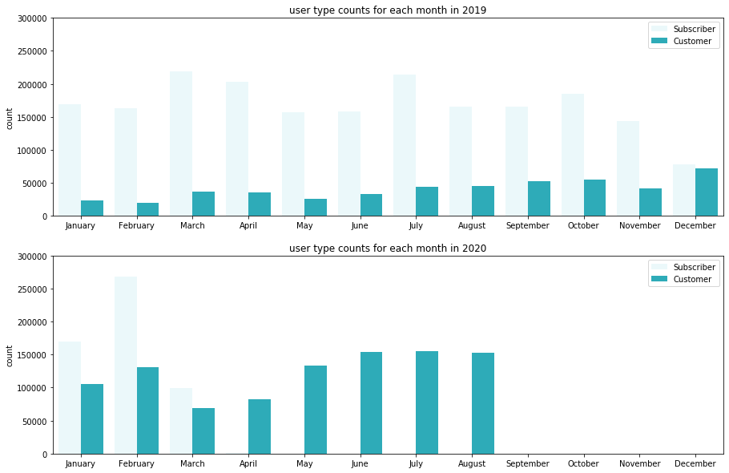

```python
df_2019 = df[df['year'] == 2019]
df_2020 = df[df['year'] == 2020]

color_palt = sb.color_palette()[9]

fig, ax = plt.subplots(nrows = 2, figsize = [15,10])
order_val = ['January', 'February', 'March', 'April', 'May', 'June', 'July', 'August', 'September', 'October',
             'November', 'December']

sb.countplot(data=df_2019, x='month', hue='user_type', hue_order = ['Subscriber', 'Customer'], ax=ax[0], order=np.arange(1,13,1), color=color_palt);
ax[0].set_title('user type counts for each month in 2019');
ax[0].set_xticklabels(order_val);
ax[0].legend(loc='upper right');
ax[0].set_xlabel('');
ax[0].set_ylim([0, 300000]);


sb.countplot(data=df_2020, x='month', hue='user_type', hue_order = ['Subscriber', 'Customer'], ax=ax[1],  order=np.arange(1,13,1), color=color_palt);
ax[1].set_title('user type counts for each month in 2020');
ax[1].set_xticklabels(order_val);
ax[1].legend(loc='upper right');
ax[1].set_xlabel('');
ax[1].set_ylim([0, 300000]);

fig.show();
```

In 2019: Subscribers are more than Customers in all months.

## Rides Starting hours for each day in each year

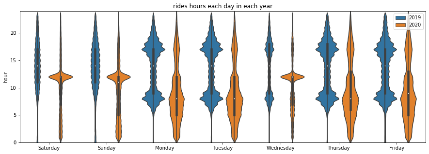

```python
order_val = ['Saturday', 'Sunday', 'Monday', 'Tuesday', 'Wednesday', 'Thursday', 'Friday']

fig= plt.subplots(figsize = [15,5])

sb.violinplot(data=df, x='day', y='hour', order=order_val, hue='year');
plt.title('rides hours each day in each year');
#plt.ylabel('duration(mins)');
plt.ylim([0, 24]);
plt.xlabel('');
plt.legend(loc='upper right');
```

In 2019, on average the rides on weekdays starts at 7-8 am and 5 pm which is the start and end hours of the employees. At weekend, the rides starts from around 7 to 12 am with a normal distrubtuion with a mean around 2 pm

In 2020, the rides start on average at 12pm on weekends. The rides start on average on 7-8 am and smaller portion starts at 5 pm at weekdays. Except for Wednesdays, it's much like the weekends which the rides start on average at 12pm.

## Conclusion

#### It's observed that Covid-19 has significant effect on the rides, and the behavior observed for 2020 is different that in 2019. The following is the observed differences between 2019 and 2020:

> 1- The average duration in min for all days of 2020 are greater that in 2019. This shows that there is a correlation between Covid-19 and increase of the ride duration.